# 2018201743-张嘉辰-第六周作业

张嘉辰

2020年10月22日

# 2.4 符号检验和Wilcoxon符号秩检验

要检验的问题是两场联赛三分球得分次数是否存在显著性差异。

进行符号检验和Wilcoxon符号秩检验，原假设和备择假设为：

H0:$P(第一场联赛三分球得分)=P(第一场联赛三分球得分)$，两场联赛三分球得分次数不存在显著性差异

H1:$P(第一场联赛三分球得分)≠P(第二场联赛三分球得分)$，两场联赛三分球得分次数是否存在显著性差异

## (1)符号检验

```r
goal <- data.frame(L1 = c(91, 46, 108, 99, 110, 105, 191, 57, 34, 81),
                 L2 = c(81, 51, 63, 51, 46, 45, 66, 64, 90, 28))
attach(goal)
#配对样本比较中的符号检验
#第二场联赛的进球次数大于第一场的样本个数记为S1
S1_fun <- function(x1, x2){ifelse(x1<x2, yes = 1, no = 0)}
S1 <- sum(mapply(S1_fun, L1, L2))
#第二场联赛的进球次数小于第一场的样本个数记为S2
S2_fun <- function(x1, x2){ifelse(x1>x2, yes = 1, no = 0)}
S2 <- sum(mapply(S2_fun, L1, L2))
n <- S1 + S2
#进行符号检验，计算p值
p_sign <- 2*dbinom(S1, n, 1/2)
p_sign
```

```
## [1] 0.234375
```

```r
#输出符号检验的结果
if(p_sign < 0.05)
{print("符号检验p<0.05，
       拒绝原假设，认为两场联赛三分球得分次数存在显著性差异")}else
       {print("符号检验p≥0.05，没有充足的理由拒绝原假设，不能认为两场联赛三分球得分次数存在显著性差异")}
```

```
## [1] "符号检验p≥0.05，没有充足的理由拒绝原假设，不能认为两场联赛三分球得分次数存在显著性差异"
```

## (2)配对Wilcoxon符号秩检验

```r
goal <- data.frame(L1 = c(91, 46, 108, 99, 110, 105, 191, 57, 34, 81),
                 L2 = c(81, 51, 63, 51, 46, 45, 66, 64, 90, 28))
attach(goal)
L21 <- L2-L1
#进行配对Wilcoxon符号秩检验
wtest <- wilcox.test(L21, alternative = "two.sided", conf.int = TRUE)
#计算p值
p_wil <- wtest$p.value
p_wil
```

```
## [1] 0.08398438
```

```r
#输出检验结果
if(p_wil < 0.05)
{print("Wilcoxon符号秩检验p<0.05，拒绝原假设，认为两场联赛三分球得分次数存在显著性差异")}else
       {print("Wilcoxon符号秩检验p≥0.05，没有充足的理由拒绝原假设，不能认为两场联赛三分球得分次数存在显著性差异")}
```

```
## [1] "Wilcoxon符号秩检验p≥0.05，没有充足的理由拒绝原假设，不能认为两场联赛三分球得分次数存在显著性差异"
```

在α=0.05下，尽管符号检验和Wilcoxon符号秩检验都没有充足的理由拒绝原假设，但是符号检验的p值为p_sign=0.234375，Wilcoxon符号秩检验的p值为0.08398438，即Wilcoxon符号秩检验的p值更小。

这表明在对称性的假定下，Wilcoxon符号秩检验采用了比符号检验更多的信息，因此，在假定总体分布的对称性成立的情况下得到更可靠的结论。

但是，如果对称性不成立，则还是符号检验的结果更可靠。

# 2.5 随机游程检验

要检验的问题是该信号是否为纯粹随机干扰。

进行随机游程检验，原假设和备择假设为：

H0:0和1出现顺序随机 vs H1:0和1出现顺序不随机

```r
#输入数据，需要转化为因子类型
signal <- factor(c(0,1,0,1,1,1,0,0,1,1,0,0,0,0,1,1,1,1,1,1,1,1,1,0,1,0,0,1,1,1,0,1,0,1,0,1,0,0,
              0,0,0,0,0,0,1,0,1,1,0,0,1,1,1,0,1,0,1,0,0,0,1,0,0,1,0,1,0,1,0,0,0,0,0,0,0,0))

library(tseries)
#进行随机游程检验
run_test <- runs.test(signal, alternative = "two.sided")
#p值
p_run <- run_test$p.value
p_run
```

```
## [1] 0.7122645
```

```r
if(p_run < 0.05)
{print("随机游程检验p<0.05，拒绝原假设，认为信号不是纯粹随机干扰")}else
       {print("随机游程检验p≥0.05，没有充足的理由拒绝原假设，认为信号是随机干扰")}
```

```
## [1] "随机游程检验p≥0.05，没有充足的理由拒绝原假设，认为信号是随机干扰"
```

# 2.14 Wilcoxon秩和检验与随机游程检验

## (1)Wilcoxon秩和检验

要检验的问题是两种生产方法是否有显著差异。

进行不配对的两样本的Wilcoxon检验，即进行Wilcoxon秩和检验。

原假设和备择假设为：

则原假设和备择假设为：

H0:两种生产方法没有显著差异，总体A的中位数等于总体B的中位数

H1:两种生产方法有显著差异，总体A的中位数不等于总体B的中位数

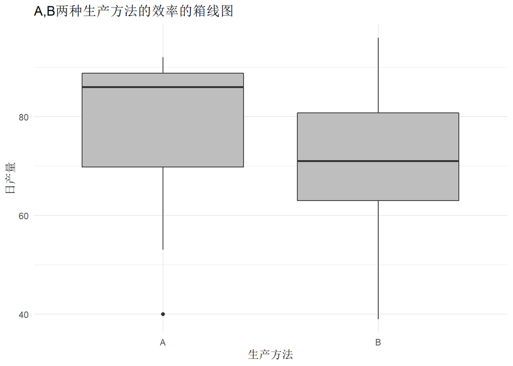

```r
A <- c(92,69,72,40,90,53,85,87,89,88)
B <- c(78,95,58,65,39,67,64,75,60,80,83,96)
#构建数据框，是长表的形式
#第一类为A或者B，并转化为因子类型；第二列为日产量的值
eff_df <- data.frame(
  method = as.factor(c(rep("A", 10), rep("B", 12))),
  eff = c(
    92,69,72,40,90,53,85,87,89,88,
    78,95,58,65,39,67,64,75,60,80,83,96
  )
)
#画出A和B的分组箱线图，通过分组箱线图可以大概看到A和B两组数据的分布的差异
library(ggplot2)
ggplot(eff_df, aes(x = method, y = eff)) +
  geom_boxplot(fill = "grey") +
  theme_minimal() +
  labs(x = "生产方法", y = "日产量",
       title = "A,B两种生产方法的效率的箱线图")
```

```r
#进行Wilcoxon秩和检验
wilcox.test(eff_df$eff~eff_df$method, paired = FALSE)
```

```
##
##  Wilcoxon rank sum test
##
## data:  eff_df$eff by eff_df$method
## W = 74, p-value = 0.381
## alternative hypothesis: true location shift is not equal to 0
```

```r
#提取p值
p <- wilcox.test(eff_df$eff~eff_df$method, paired = FALSE)$p.value
p
```

```
## [1] 0.380972
```

```r
#p=0.381>0.05，因此没有充足的理由拒绝原假设，即没有充足的证据认为两种生产方法的生产效率有显著差异

#补充：对于有结数据，wilcox.test()函数将采用正态分布进行近似计算，同时输出警告“无法精确计算带连结的p值”，此时可以用coin包中的wilcox_test()函数进行精确计算。
#此题中的数据没有结，所以两者输出的p值相同。
library(coin)
wilcox_test(eff_df$eff~eff_df$method, distribution = exact())
```

```
##
##  Exact Wilcoxon-Mann-Whitney Test
##
## data:  eff_df$eff by eff_df$method (A, B)
## Z = 0.92313, p-value = 0.381
## alternative hypothesis: true mu is not equal to 0
```

## (2)随机游程检验

将A方法的数据标识为0，将B方法的数据标识为1

将A方法和B方法的数据组合后排序，得到对应的0和1的值，作为随机游程检验的二元序列。

```r
A <- c(92,69,72,40,90,53,85,87,89,88)
B <- c(78,95,58,65,39,67,64,75,60,80,83,96)
#标识为0的数据个数，即A组数据的个数
n0 <- length(A)
#标识为1的数据个数，即B组数据的个数
n1 <- length(B)
#生成数据框，第一列为0（代表A）或1（代表B），第二列为A和B的日产量，每一行来自同一个样本
AB_df <- data.frame(sequen = c(rep(0, n0), rep(1, n1)), value = c(A, B))
#将数据框按照日产量排序
AB_order <- AB_df[order(AB_df[,2]), ]
#排序后得到对应的0和1的序列，作为随机游程检验的二元序列
#转化为因子类型
seq_AB <- as.factor(AB_order$sequen)
seq_AB
```

```
##  [1] 1 0 0 1 1 1 1 1 0 0 1 1 1 1 0 0 0 0 0 0 1 1
## Levels: 0 1
```

```r
library(tseries)
#进行随机游程检验
run_test_AB <- runs.test(seq_AB, alternative = "two.sided")
#p值
p_run_AB <- run_test_AB$p.value
p_run_AB
```

```
## [1] 0.03048643
```

```r
#输出检验结果
if(p_run_AB < 0.05)
{print("随机游程检验p<0.05，拒绝原假设，认为A和B两种生产方法有显著差异")}else
       {print("随机游程检验p≥0.05，       没有充足的理由拒绝原假设，       认为A和B两种生产方法没有显著差异")}
```

```
## [1] "随机游程检验p<0.05，拒绝原假设，认为A和B两种生产方法有显著差异"
```

采用Wilcoxon秩和检验与随机游程检验得到的结论不一致。因为在对称性的假定之下，Wilcoxon秩和检验采用了更多信息。也就是说，在总体分布的对称性假定下，Wilcoxon秩和检验更可靠。

但是，如果A和B所在的总体的对称性不成立，则随机游程检验的结果更可靠。

# 2.3.2 势比较实验

由于例题给出了代码，所以以下首先利用例题中的代码计算得到$\theta=2$时Wilcoxon符号秩检验的势和t检验的势。

最后，利用改进后的代码，画出$0≤\theta≤2$时，Wilcoxon符号秩检验和t检验的势的变化曲线，可以看到两种检验的势均随着$\theta$的增大而增大，且Wilcoxon符号秩检验的势始终大于t检验的势。

## (1)例题给出的代码

计算$\theta=2$的情况下，Wilcoxon符号秩检验的势和t检验的势

```r
set.seed(1234)
#样本量
n <- 30
df <- 2
nsims <- 10000
mu <- 2
collwil <- rep(0,nsims)
collt <- rep(0,nsims)
for(i in 1:nsims){
#从t分布中抽样
  x <- rt(n,df) + mu
#对每组样本进行Wilcoxon符号秩检验
  wil <- wilcox.test(x)
  collwil[i] <- wil$p.value
#对每组样本进行t检验
  ttest <- t.test(x)
  collt[i] <- ttest$p.value
}
powwil <- rep(0,nsims)
#Wilcoxon符号秩检验的势
powwil[collwil <= .05] <- 1
powerwil <- sum(powwil)/nsims
powerwil
```

```
## [1] 0.9999
```

```r
powt <- rep(0,nsims)
#t检验的势
powt[collt <= .05] <- 1
powert <- sum(powt)/nsims
powert
```

```
## [1] 0.9365
```

## (2)代码改进

在例题代码的基础上进行了部分改进。

与例题所给代码的主要区别：

1.将for循环改为apply()函数，降低程序的运行时间

2.由于apply()函数得到的结果为list类型，每个元素为每组样本的检验结果，

所以运用purrr包中的map()函数提取检验结果中的p值，得到每组样本检验结果的p值构成的列表，

再用unlist()函数转化为向量。

3.用ifelse()函数标出Wilcoxon符号秩检验和于t检验中满足$p≤0.05$的样本

```r
set.seed(1234)
#每一组的样本量为n
n <- 30
df <- 2
#进行nsims次
nsims <- 10000
theta <- 2
collwil <- rep(0,nsims)
collt <- rep(0,nsims)
#抽nsims组样本，每组样本的样本量均为n
x_rand <- matrix(rt(n*nsims, df), ncol = n, nrow = nsims) + theta
#对每组样本进行Wilcoxon符号秩检验
wil <- apply(x_rand, 1, wilcox.test)
#对每组样本进行t检验
ttest <- apply(x_rand, 1, t.test)
#得到的wil和ttest的类型是列表，列表中的每个元素分别为每一组样本进行Wilcoxon符号秩检验或t检验的结果。
#所以运用purrr包中的map函数，提取列表中的每个元素中的p.value，即提取每组样本进行Wilcoxon符号秩检验和t检验得到的p值
#map()函数输出的结果的类型是列表，所以用unlist()函数转化为向量形式
library(purrr)
collwil <- unlist(map(wil, "p.value"))
collt <- unlist(map(ttest, "p.value"))

#Wilcoxon符号秩检验的势
powwil <- ifelse(collwil<=0.05, 1, 0)
powerwil <- sum(powwil)/nsims
powerwil
```

```
## [1] 0.9994
```

```r
#t检验的势
powt <- ifelse(collt<=0.05, 1, 0)
powert <- sum(powt)/nsims
powert
```

```
## [1] 0.9384
```

## (3)检验的势的曲线图

画出0≤θ≤2时，Wilcoxon符号秩检验和t检验的势的变化曲线。

从图上可以看出，在$0≤\theta≤2$时，Wilcoxon符号秩检验的势均大于t检验的势，而且可以看到势随着$\theta$的变化。

计算势的代码与(2)中改进的代码相同。

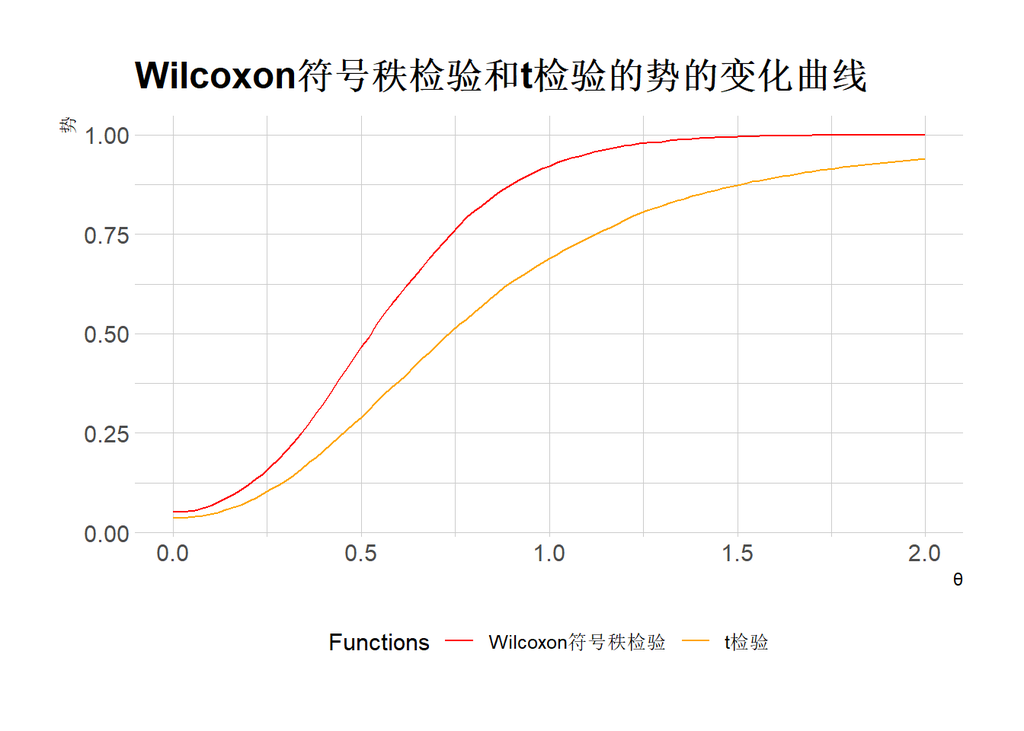

```r
set.seed(1234)


#每一组的样本量为n
n <- 30
df <- 2
#进行nsims次抽样
nsims <- 10000
theta <- seq(from = 0, to = 2, by = 0.01)
collwil <- rep(0,nsims)
collt <- rep(0,nsims)
x_rand <- matrix(rt(n*nsims, df), ncol = n, nrow = nsims)
library(purrr)
#计算势的代码与(2)中改进的代码相同，这里为了画图，改写成函数形式
#计算Wilcoxon符号秩检验的p值的函数
wilpower_fun <- function(theta1){
  x_rand_theta <- x_rand + theta1
  wil <- apply(x_rand_theta, 1, wilcox.test)
  collwil <- unlist(map(wil, "p.value"))
  powwil <- ifelse(collwil<=0.05, 1, 0)
  powerwil <- sum(powwil)/nsims
  return(powerwil)
}
#计算t检验的p值的函数
tpower_fun <- function(theta1){
  x_rand_theta <- x_rand + theta1
  ttest <- apply(x_rand_theta, 1, t.test)
  collt <- unlist(map(ttest, "p.value"))
  powt <- ifelse(collt<=0.05, 1, 0)
  powert <- sum(powt)/nsims
  return(powert)
}
#对数据框的每一行数据（即每一组样本）进行Wilcoxon符号秩检验，得到每一组样本的p值
wil_f <- function(x){
  apply(data.frame(x), 1, wilpower_fun)
}
#对数据框的每一行数据（即每一组样本）进行t检验，得到每一组样本的p值
t_f <- function(x){
  apply(data.frame(x), 1, tpower_fun)
}
#构建数据框，用来画图
plot.range.wil <- data.frame(x=c(0,2), Functions = factor(1))
plot.range.t <- data.frame(x=c(0,2), Functions = factor(2))

library(ggplot2)
library(hrbrthemes)
#画出两种检验的p值的变化曲线
ggplot(NULL, aes(x=x, color = Functions)) +
#画出Wilcoxon符号秩检验的势的变化曲线，颜色为红色
  geom_function(data = plot.range.wil, fun = wil_f)+
#画出t检验的势的变化曲线，颜色为橙色
  geom_function(data = plot.range.t, fun = t_f) +
  scale_colour_manual(values = c("red", "orange"),
                      labels = c("Wilcoxon符号秩检验", "t检验")) +
  theme_ipsum() +
  theme(legend.position = "bottom") +
  labs(title="Wilcoxon符号秩检验和t检验的势的变化曲线",
       y = "势", x="θ")
```